# Machine Learning Project

Sum up of the project

Can we predict the risk of developing a tumor based on an individual’s symptoms? We aim to design a simple artificial intelligence system that determines whether a patient should be concerned given their observed symptoms. Using Python and basic machine learning tools, we will train a supervised classification model on a disease–symptom dataset.

*The data*

We use Disease-Symptom Dataset under World Bank license and found in https://www.kaggle.com/datasets/dhivyeshrk/diseases-and-symptoms-dataset. This dataset could not be used in a real research project, but is relevant for a project aimed at manipulating and understanding machine learning. It contains a list of 773 unique diseases associated with 377 symptoms. Theses symptoms are coded as dummy variable: 1 if the symptom is relevant to the disease, 0 otherwise. We end up with 246,000 samples.

**Taking a look at the data**

```python
import pandas as pd

df = pd.read_csv("Final_Augmented_dataset_Diseases_and_Symptoms.csv")

# Je crée un sample pour que ça tourne plus vite
df_sample = df.sample(1000).copy()
df.sample(10)
```

|  | diseases | anxiety and nervousness | depression | shortness of breath | depressive or psychotic symptoms | sharp chest pain | dizziness | insomnia | abnormal involuntary movements | chest tightness | ... | stuttering or stammering | problems with orgasm | nose deformity | lump over jaw | sore in nose | hip weakness | back swelling | ankle stiffness or tightness | ankle weakness | neck weakness |
| --- | --- | --- | --- | --- | --- | --- | --- | --- | --- | --- | --- | --- | --- | --- | --- | --- | --- | --- | --- | --- | --- |
| 56438 | chronic otitis media | 0 | 0 | 0 | 0 | 0 | 0 | 0 | 0 | 0 | ... | 0 | 0 | 0 | 0 | 0 | 0 | 0 | 0 | 0 | 0 |
| 92023 | carpal tunnel syndrome | 0 | 0 | 0 | 0 | 0 | 0 | 0 | 0 | 0 | ... | 0 | 0 | 0 | 0 | 0 | 0 | 0 | 0 | 0 | 0 |
| 60447 | degenerative disc disease | 0 | 0 | 0 | 0 | 0 | 0 | 0 | 0 | 0 | ... | 0 | 0 | 0 | 0 | 0 | 0 | 0 | 0 | 0 | 0 |
| 243367 | eczema | 0 | 0 | 0 | 0 | 0 | 0 | 0 | 0 | 0 | ... | 0 | 0 | 0 | 0 | 0 | 0 | 0 | 0 | 0 | 0 |
| 148966 | ear drum damage | 0 | 0 | 0 | 0 | 0 | 0 | 0 | 0 | 0 | ... | 0 | 0 | 0 | 0 | 0 | 0 | 0 | 0 | 0 | 0 |
| 46040 | endometriosis | 0 | 0 | 0 | 0 | 0 | 0 | 0 | 0 | 0 | ... | 0 | 0 | 0 | 0 | 0 | 0 | 0 | 0 | 0 | 0 |
| 186487 | liver disease | 0 | 0 | 1 | 0 | 0 | 0 | 0 | 0 | 0 | ... | 0 | 0 | 0 | 0 | 0 | 0 | 0 | 0 | 0 | 0 |
| 14828 | teething syndrome | 0 | 0 | 0 | 0 | 0 | 0 | 0 | 0 | 0 | ... | 0 | 0 | 0 | 0 | 0 | 0 | 0 | 0 | 0 | 0 |
| 66678 | bone cancer | 0 | 0 | 0 | 0 | 0 | 0 | 0 | 0 | 0 | ... | 0 | 0 | 0 | 0 | 0 | 0 | 0 | 0 | 0 | 0 |
| 1124 | atrophic vaginitis | 0 | 0 | 0 | 0 | 0 | 0 | 0 | 0 | 0 | ... | 0 | 0 | 0 | 0 | 0 | 0 | 0 | 0 | 0 | 0 |

10 rows × 378 columns

```python
df.shape
```

```
(246945, 378)
```

There are 246,945 observations for 378 variables. We need to clean this a bit to make it more useful and relevant.

```python
df.dtypes
```

```
diseases                            object
anxiety and nervousness              int64
depression                           int64
shortness of breath                  int64
depressive or psychotic symptoms     int64
                                     ...
hip weakness                         int64
back swelling                        int64
ankle stiffness or tightness         int64
ankle weakness                       int64
neck weakness                        int64
Length: 378, dtype: object
```

```python
df.describe()
```

|  | anxiety and nervousness | depression | shortness of breath | depressive or psychotic symptoms | sharp chest pain | dizziness | insomnia | abnormal involuntary movements | chest tightness | palpitations | ... | stuttering or stammering | problems with orgasm | nose deformity | lump over jaw | sore in nose | hip weakness | back swelling | ankle stiffness or tightness | ankle weakness | neck weakness |
| --- | --- | --- | --- | --- | --- | --- | --- | --- | --- | --- | --- | --- | --- | --- | --- | --- | --- | --- | --- | --- | --- |
| count | 246945.000000 | 246945.000000 | 246945.000000 | 246945.000000 | 246945.000000 | 246945.000000 | 246945.000000 | 246945.000000 | 246945.000000 | 246945.000000 | ... | 246945.0 | 246945.0 | 246945.0 | 246945.0 | 246945.000000 | 246945.0 | 246945.0 | 246945.0 | 246945.000000 | 246945.0 |
| mean | 0.039235 | 0.042746 | 0.086440 | 0.061001 | 0.097252 | 0.069943 | 0.039410 | 0.040572 | 0.037871 | 0.024876 | ... | 0.0 | 0.0 | 0.0 | 0.0 | 0.001385 | 0.0 | 0.0 | 0.0 | 0.000073 | 0.0 |
| std | 0.194155 | 0.202285 | 0.281014 | 0.239333 | 0.296302 | 0.255051 | 0.194568 | 0.197296 | 0.190884 | 0.155747 | ... | 0.0 | 0.0 | 0.0 | 0.0 | 0.037189 | 0.0 | 0.0 | 0.0 | 0.008537 | 0.0 |
| min | 0.000000 | 0.000000 | 0.000000 | 0.000000 | 0.000000 | 0.000000 | 0.000000 | 0.000000 | 0.000000 | 0.000000 | ... | 0.0 | 0.0 | 0.0 | 0.0 | 0.000000 | 0.0 | 0.0 | 0.0 | 0.000000 | 0.0 |
| 25% | 0.000000 | 0.000000 | 0.000000 | 0.000000 | 0.000000 | 0.000000 | 0.000000 | 0.000000 | 0.000000 | 0.000000 | ... | 0.0 | 0.0 | 0.0 | 0.0 | 0.000000 | 0.0 | 0.0 | 0.0 | 0.000000 | 0.0 |
| 50% | 0.000000 | 0.000000 | 0.000000 | 0.000000 | 0.000000 | 0.000000 | 0.000000 | 0.000000 | 0.000000 | 0.000000 | ... | 0.0 | 0.0 | 0.0 | 0.0 | 0.000000 | 0.0 | 0.0 | 0.0 | 0.000000 | 0.0 |
| 75% | 0.000000 | 0.000000 | 0.000000 | 0.000000 | 0.000000 | 0.000000 | 0.000000 | 0.000000 | 0.000000 | 0.000000 | ... | 0.0 | 0.0 | 0.0 | 0.0 | 0.000000 | 0.0 | 0.0 | 0.0 | 0.000000 | 0.0 |
| max | 1.000000 | 1.000000 | 1.000000 | 1.000000 | 1.000000 | 1.000000 | 1.000000 | 1.000000 | 1.000000 | 1.000000 | ... | 0.0 | 0.0 | 0.0 | 0.0 | 1.000000 | 0.0 | 0.0 | 0.0 | 1.000000 | 0.0 |

8 rows × 377 columns

```python
# Let's take a look at the number of diseases we have:
len(df["diseases"].unique())
# There are 773 of them, let's take a look some of them:
for disease in df_sample["diseases"].unique():
    print(f"number of {disease}: {df_sample["diseases"].value_counts()[disease]}")
# Some are numerous, others are few
```

```
number of threatened pregnancy: 4
number of otitis externa (swimmer's ear): 3
number of ectopic pregnancy: 3
number of nose disorder: 8
number of pterygium: 1
number of erectile dysfunction: 4
number of broken tooth: 1
number of eating disorder: 2
number of scoliosis: 2
number of pleural effusion: 4
number of hypertension of pregnancy: 1
number of sickle cell crisis: 3
number of myopia: 2
number of laryngitis: 4
number of dental caries: 6
number of gout: 6
number of hypoglycemia: 5
number of peripheral arterial embolism: 3
number of heart failure: 5
number of skin cancer: 2
number of corneal abrasion: 3
number of acne: 3
number of pelvic inflammatory disease: 4
number of vulvodynia: 5
number of noninfectious gastroenteritis: 9
number of varicocele of the testicles: 4
number of multiple sclerosis: 4
number of seborrheic keratosis: 4
number of endometriosis: 2
number of angina: 7
number of personality disorder: 13
number of strep throat: 8
number of temporary or benign blood in urine: 3
number of mitral valve disease: 2
number of conjunctivitis due to allergy: 4
number of irritable bowel syndrome: 1
number of anxiety: 6
number of ischemic heart disease: 7
number of abdominal hernia: 2
number of gastrointestinal hemorrhage: 4
```

[output cut: 334 more lines]

```
number of granuloma inguinale: 1
number of hypertensive heart disease: 2
number of dislocation of the shoulder: 1
number of jaw disorder: 2
number of envenomation from spider or animal bite: 1
number of intestinal disease: 1
number of oppositional disorder: 1
number of brain cancer: 1
number of retinal detachment: 1
number of intestinal cancer: 1
number of trigeminal neuralgia: 1
number of vocal cord polyp: 1
number of tension headache: 1
number of induced abortion: 1
number of chronic sinusitis: 1
```

**Pre-processing**

Due to our poor skills in medicine, and to improve both efficiency and relevance, we will use an AI to store the diseases into larger, more comprehensive categories. We will ask it to do it just as we saw in class, with a "if ... in disease... yada yada".

```python
def group_disease(disease):
    disease = disease.lower()

    # Maladies cardiovasculaires
    if any(x in disease for x in ["heart", "coronary", "hypertension", "cardiomyopathy", "aortic", "stroke", "ischemia", "atrial", "valve", "arrhythmia", "thrombosis", "embolism", "angina", "arterial", "vascular"]):
        return "cardiovascular"

    # Maladies respiratoires
    elif any(x in disease for x in ["asthma", "copd", "emphysema", "pulmonary", "bronchiolitis", "respiratory", "pneumonia", "bronchitis", "breath", "lung", "tracheal", "laryngeal", "pleural", "pneumothorax"]):
        return "respiratory"

    # Maladies métaboliques / endocriniennes
    elif any(x in disease for x in ["diabetes", "thyroid", "obesity", "metabolic", "hypoglycemia", "hyperglycemia", "parathyroid", "pituitary", "adrenal", "hormone", "cushing", "graves", "hashimoto"]):
        return "metabolic_endocrine"

    # Maladies neurologiques / mentales
    elif any(x in disease for x in ["depression", "anxiety", "parkinson", "dementia", "adhd", "migraine", "epilepsy", "neuropathy", "stroke", "disorder", "bipolar", "schizophrenia", "psychotic", "panic", "ptsd", "traumatic", "stress", "mental", "neurological", "brain", "alzheimer", "huntington", "als", "sclerosis", "palsy", "nerve"]):
        return "neurological_psych"

    # Maladies digestives / hépatiques
    elif any(x in disease for x in ["liver", "gastro", "pancreatitis", "esophagus", "stomach", "intestinal", "ulcer", "nash", "hepatitis", "crohn", "colitis", "ibs", "diverticular", "cirrhosis", "cholecyst", "bile", "bowel"]):
        return "digestive_hepatic"

    # Maladies rénales / urologiques
    elif any(x in disease for x in ["kidney", "renal", "urethral", "bladder", "prostate", "urine", "urinary", "urologic", "uric", "urea"]):
        return "renal_urological"

    # Maladies infectieuses
    elif any(x in disease for x in ["infection", "viral", "bacterial", "fungal", "dengue", "hiv", "malaria", "tuberculosis", "meningitis", "sepsis", "pneumonia", "hepatitis", "herpes", "gonorrhea", "chlamydia", "syphilis", "lyme", "fever", "cold", "flu", "wart", "lice", "scabies"]):
        return "infectious"

    # Maladies musculo-squelettiques
    elif any(x in disease for x in ["fracture", "injury", "arthritis", "osteoporosis", "spine", "knee", "shoulder", "ankle", "foot", "hip", "bone", "cartilage", "tendon", "ligament", "muscle", "sprain", "strain", "dislocation", "bursitis", "carpal tunnel"]):
        return "musculoskeletal"

    # Maladies dermatologiques
    elif any(x in disease for x in ["skin", "dermatitis", "eczema", "psoriasis", "rash", "acne", "wound", "burn", "ulcer", "sore", "wart", "fungal", "abscess", "cyst", "mole", "lesion", "blister", "impetigo"]):
        return "dermatological"

    # Maladies oncologiques
    elif any(x in disease for x in ["cancer", "tumor", "carcinoma", "lymphoma", "sarcoma", "leukemia", "malignant", "ependymoma", "meningioma", "adenoma", "polyp"]):
        return "oncology"

    # Maladies gynécologiques / obstétriques
    elif any(x in disease for x in ["pregnancy", "uterine", "ovarian", "endometriosis", "fibroids", "menopause", "vagina", "placenta", "cervix", "womb", "female", "gynecolog", "obstetric", "natal", "abortion", "ectopic", "preeclamp"]):
        return "gynecological_obstetric"

    # Maladies ophtalmologiques / auditives
    elif any(x in disease for x in ["eye", "glaucoma", "retina", "vision", "hearing", "tinnitus", "otitis", "ocular", "conjunctivitis", "cataract", "cornea", "optic", "visual", "deaf", "ear", "auditory"]):
        return "ophthalmology_audiology"

    # Maladies hématologiques / immunologiques
    elif any(x in disease for x in ["anemia", "bleeding", "coagulation", "immunodeficiency", "leukemia", "lymphoma", "sickle", "hemophil", "thrombocyt", "polycyth"]):
        return "hematological_immunological"

    # Autres / non classés
    else:
        return "other"

df["group diseases"] = df["diseases"].apply(group_disease)
#df_sample["group diseases"] = df["diseases"].apply(group_disease)

# In case here is the list of the above grouped categories:
#["cardiovascular", "respiratory", "metabolic_endocrine", "neurological_psych", "digestive_hepatic", "renal_urological", "infectious", "musculoskeletal", "dermatological", "oncology", "gynecological_obstetric", "ophthalmology_audiology", "hematological_immunological", "other"]
```

Now that we have grouped many of them, let's take some time to look at them again:

```python
df.head(10).style

for disease in df["group diseases"].unique():
    print(f"number of {disease}: {df["group diseases"].value_counts()[disease]}")
```

```
number of neurological_psych: 29611
number of oncology: 2162
number of other: 104838
number of musculoskeletal: 17141
number of dermatological: 16460
number of metabolic_endocrine: 2078
number of ophthalmology_audiology: 13379
number of gynecological_obstetric: 6289
number of digestive_hepatic: 12872
number of cardiovascular: 11142
number of respiratory: 8220
number of hematological_immunological: 2635
number of infectious: 14021
number of renal_urological: 6097
```

## Testing different cleaning choices

### Method 1: discarding low variance symptoms

Should we remove all the other category? I think so, as they are not relevant to compute our tumor, but we will see that.

Now, lets turn to our features: the symptoms. They may be too numerous. The IA mention doing a variance threshold method, I look at the documentation on the Internet and try to apply it with the help of the AI. For the AI, a threshold of 0.01 or 0.05 seem relevant. In any case, the goal is to remove features that are too constant between diseases to be relevant; they do not allow to differentiate between disease

```python
from sklearn.feature_selection import VarianceThreshold
# First, let's identify which columns are symptom features (not metadata)
# Assuming 'diseases' and 'group diseases' are the target/metadata columns

symptom_columns = [col for col in df.columns if col not in ['diseases', 'group diseases']]
X = df[symptom_columns]

print(f"Initial number of symptoms: {len(symptom_columns)}")
print(f"Dataset shape: {X.shape}")

# Apply Variance Threshold
# For binary features (0/1), threshold is based on Var(X) = p(1-p)
# threshold=0.01 removes features that appear in less than ~1% or more than ~99% of cases
selector = VarianceThreshold(threshold=0.01)
X_filtered = selector.fit_transform(X)

# Get the names of selected features
selected_features = X.columns[selector.get_support()].tolist()
removed_features = X.columns[~selector.get_support()].tolist()

print(f"\nAfter variance threshold (0.01):")
print(f"Number of symptoms remaining: {len(selected_features)}")
print(f"Number of symptoms removed: {len(removed_features)}")
print(f"New shape: {X_filtered.shape}")

# Show some removed features (the ones with very low variance)
print(f"\nSample of removed symptoms (low variance):")
print(removed_features[:10])
```

```
Initial number of symptoms: 377
Dataset shape: (246945, 377)

After variance threshold (0.01):
Number of symptoms remaining: 146
Number of symptoms removed: 231
New shape: (246945, 146)

Sample of removed symptoms (low variance):
['breathing fast', 'throat swelling', 'lump in throat', 'throat feels tight', 'groin mass', 'emotional symptoms', 'elbow weakness', 'back weakness', 'pus in sputum', 'symptoms of the scrotum and testes']
```

```python
# Create a new dataframe with only selected symptoms + target/metadata columns
df_method1 = df[['group diseases'] + ['diseases'] + selected_features].copy()

print(f"Cleaned dataset shape: {df_method1.shape}")
print(f"\nCleaned dataset columns: {df_method1.columns.tolist()[:10]}... (showing first 10)")

# You can adjust the threshold if needed:
# threshold=0.001 -> removes very rare symptoms (stricter)
# threshold=0.05  -> removes more symptoms (less strict)
# threshold=0.0   -> keeps all features with any variance
```

```
Cleaned dataset shape: (246945, 148)

Cleaned dataset columns: ['group diseases', 'diseases', 'anxiety and nervousness', 'depression', 'shortness of breath', 'depressive or psychotic symptoms', 'sharp chest pain', 'dizziness', 'insomnia', 'abnormal involuntary movements']... (showing first 10)
```

```python
df_method1
```

|  | group diseases | diseases | anxiety and nervousness | depression | shortness of breath | depressive or psychotic symptoms | sharp chest pain | dizziness | insomnia | abnormal involuntary movements | ... | sweating | swollen eye | symptoms of bladder | itching of skin | skin dryness, peeling, scaliness, or roughness | skin irritation | warts | skin rash | low self-esteem | mouth pain |
| --- | --- | --- | --- | --- | --- | --- | --- | --- | --- | --- | --- | --- | --- | --- | --- | --- | --- | --- | --- | --- | --- |
| 0 | neurological_psych | panic disorder | 1 | 0 | 1 | 1 | 0 | 0 | 0 | 0 | ... | 0 | 0 | 0 | 0 | 0 | 0 | 0 | 0 | 0 | 0 |
| 1 | neurological_psych | panic disorder | 0 | 0 | 1 | 1 | 0 | 1 | 1 | 0 | ... | 0 | 0 | 0 | 0 | 0 | 0 | 0 | 0 | 0 | 0 |
| 2 | neurological_psych | panic disorder | 1 | 1 | 1 | 1 | 0 | 1 | 1 | 0 | ... | 0 | 0 | 0 | 0 | 0 | 0 | 0 | 0 | 0 | 0 |
| 3 | neurological_psych | panic disorder | 1 | 0 | 0 | 1 | 0 | 1 | 1 | 1 | ... | 0 | 0 | 0 | 0 | 0 | 0 | 0 | 0 | 0 | 0 |
| 4 | neurological_psych | panic disorder | 1 | 1 | 0 | 0 | 0 | 0 | 1 | 1 | ... | 0 | 0 | 0 | 0 | 0 | 0 | 0 | 0 | 0 | 0 |
| ... | ... | ... | ... | ... | ... | ... | ... | ... | ... | ... | ... | ... | ... | ... | ... | ... | ... | ... | ... | ... | ... |
| 246940 | dermatological | open wound of the nose | 0 | 0 | 0 | 0 | 0 | 0 | 0 | 0 | ... | 0 | 0 | 0 | 0 | 0 | 0 | 0 | 0 | 0 | 0 |
| 246941 | dermatological | open wound of the nose | 0 | 0 | 0 | 0 | 0 | 0 | 0 | 0 | ... | 0 | 0 | 0 | 0 | 0 | 0 | 0 | 0 | 0 | 0 |
| 246942 | dermatological | open wound of the nose | 0 | 0 | 0 | 0 | 0 | 0 | 0 | 0 | ... | 0 | 0 | 0 | 0 | 0 | 0 | 0 | 0 | 0 | 0 |
| 246943 | dermatological | open wound of the nose | 0 | 0 | 0 | 0 | 0 | 0 | 0 | 0 | ... | 0 | 0 | 0 | 0 | 0 | 0 | 0 | 0 | 0 | 0 |
| 246944 | dermatological | open wound of the nose | 0 | 0 | 0 | 0 | 0 | 0 | 0 | 0 | ... | 0 | 0 | 0 | 0 | 0 | 0 | 0 | 0 | 0 | 0 |

246945 rows × 148 columns

```python
def extract_group_int(disease:str):
    if disease == "cardiovascular":
        return 0
    elif disease == "respiratory":
        return 1
    elif disease == "metabolic_endocrine":
        return 2
    elif disease == "neurological_psych":
        return 3
    elif disease == "digestive_hepatic":
        return 4
    elif disease == "renal_urological":
        return 5
    elif disease == "infectious":
        return 6
    elif disease == "musculoskeletal":
        return 7
    elif disease == "dermatological":
        return 8
    elif disease == "oncology":
        return 9
    elif disease == "gynecological_obstetric":
        return 10
    elif disease == "ophthalmology_audiology":
        return 11
    elif disease == "hematological_immunological":
        return 12
    elif disease == "other":
        return 13
```

```python
df_method1["Response"] = df_method1["group diseases"].apply(extract_group_int)
```

### Method 2: adding weights

```python
# On va encoder la colonne 'group diseases' en int pour le lasso
# Claude AI me propose la solution suivante :

# d'abord on importe tous les packages nécessaires
import pandas as pd
import numpy as np
from sklearn.linear_model import LassoCV
from sklearn.linear_model import LogisticRegressionCV
from sklearn.model_selection import train_test_split
from sklearn.preprocessing import LabelEncoder
from sklearn.metrics import classification_report, confusion_matrix
import matplotlib.pyplot as plt
#import seaborn as sns
```

```python
# on prépare les données
X_lasso = df.drop(columns=['group diseases', 'diseases'])
symptom_names = X_lasso.columns.tolist()

print(symptom_names)
```

```
['anxiety and nervousness', 'depression', 'shortness of breath', 'depressive or psychotic symptoms', 'sharp chest pain', 'dizziness', 'insomnia', 'abnormal involuntary movements', 'chest tightness', 'palpitations', 'irregular heartbeat', 'breathing fast', 'hoarse voice', 'sore throat', 'difficulty s…
```

```python
# ensuite, on encode les maladies en int
#le = LabelEncoder()
#y_lasso = le.fit_transform(df['group diseases'])
#print(y_lasso)
#len(set(y_lasso)) # on compte le nombre de classes de maladies = 14 donc c'est bon, on peut continuer
```

```python
models = {}
important_symptoms_per_disease = {}
all_important_symptoms = set()

diseases_list = df['group diseases'].unique()


for idx, disease in enumerate(diseases_list, 1):
    y = (df['group diseases'] == disease).astype(int)

    n_positive = y.sum()
    print(n_positive)
    n_negative = len(y) - n_positive

    # Split train/test avec stratification
    X_train, X_test, y_train, y_test = train_test_split(
    X_lasso, y, test_size=0.2, random_state=42, stratify=y)

    lasso = LassoCV(
        cv=5,  # 5-fold cross-validation
        alphas=np.logspace(-4, 1, 30),  # 30 valeurs de régularisation
        random_state=42,
        max_iter=5000,
        n_jobs=-1  # Utilise tous les CPU disponibles
    )

    lasso.fit(X_train, y_train)

    train_score = lasso.score(X_train, y_train)
    test_score = lasso.score(X_test, y_test)

    threshold = 1e-5
    non_zero_mask = np.abs(lasso.coef_) > threshold
    important_symptoms = X_lasso.columns[non_zero_mask].tolist()

    models[disease] = lasso
    important_symptoms_per_disease[disease] = important_symptoms
    all_important_symptoms.update(important_symptoms)

    if len(important_symptoms) > 0:
        coef_abs = np.abs(lasso.coef_)
        top_indices = np.argsort(coef_abs)[-5:][::-1]
        print(f"  Top 5 symptômes :")
        for rank, idx in enumerate(top_indices, 1):
            if coef_abs[idx] > threshold:
                print(f"    {rank}. {X_lasso.columns[idx]}: {lasso.coef_[idx]:+.4f}")
```

```
29611
  Top 5 symptômes :
    1. muscle stiffness or tightness: +0.7831
    2. foot or toe stiffness or tightness: +0.7753
    3. swollen or red tonsils: +0.5203
    4. shoulder weakness: +0.4862
    5. breathing fast: +0.4436
2162
  Top 5 symptômes :
    1. vaginal bleeding after menopause: +0.3339
    2. flatulence: +0.2622
    3. vaginal dryness: +0.2127
    4. hoarse voice: +0.1669
    5. groin mass: +0.1107
104838
  Top 5 symptômes :
    1. foot or toe stiffness or tightness: -0.6815
    2. symptoms of infants: +0.6125
    3. recent weight loss: -0.5965
    4. smoking problems: +0.5683
    5. mass or swelling around the anus: +0.5226
17141
```

[output not shown]

[output cut: 38 more lines]

[output not shown]

```python
symptoms_to_keep = list(all_important_symptoms)
df_method2 = df[['group diseases'] + symptoms_to_keep].copy()

df_method2["Response"] = df_method2["group diseases"].apply(extract_group_int)
```

```python
print(f"When selecting with the lasso method, our matrix shape is now {df_method2.shape}. It means that this methos has dropped {df.shape[1] - df_method2.shape[1]} compared to the original dataset.")

df_method2.head(10)

# Let's save it for not running the cells above again:
df_method2.to_csv('dataset_reduit_lasso.csv')
```

```
When selecting with the lasso method, our matrix shape is now (246945, 317). It means that this methos has dropped 62 compared to the original dataset.
```

### Method 3: Recursive Feature Elimination (RFE)

RFE works the following way: it assigns weights to features and then recursively consider smaller and smaller sets of features. It stops when desired set of features is reached. Here, lets say we want to keep 146 features, such as we obtain a comparable dataset to the variance threshold method.

```python
from sklearn.feature_selection import RFE
from sklearn.tree import DecisionTreeClassifier

# Prepare the data (same as Method 1)
symptom_columns = [col for col in df.columns if col not in ['diseases', 'group diseases']]
X = df[symptom_columns].to_numpy()
Y = df["group diseases"].apply(extract_group_int).to_numpy()

# Step 1: Create an estimator
# RFE uses a classifier to estimate feature importance, then recursively removes least important features
# We use DecisionTreeClassifier as it's fast and interpretable
estimator = DecisionTreeClassifier(max_depth=10, random_state=42)

# Step 2: Apply RFE to select 146 features
# RFE will:
# 1. Fit the estimator on all features
# 2. Rank features by importance
# 3. Remove the least important features
# 4. Repeat until only 146 features remain
selector = RFE(estimator, n_features_to_select=146, step=1)
selector.fit(X, Y)

# Step 3: Get the selected features
selected_features_rfe = df[symptom_columns].columns[selector.support_].tolist()
print(f"Number of selected features: {len(selected_features_rfe)}")
print(f"Sample of selected features: {selected_features_rfe[:10]}")

# Step 4: Create df_method3 with selected features + metadata
df_method3 = df[['group diseases', 'diseases'] + selected_features_rfe].copy()
print(f"\ndf_method3 shape: {df_method3.shape}")

# Step 5: Add the encoded Response column
df_method3["Response"] = df_method3["group diseases"].apply(extract_group_int)
print(f"df_method3 with Response shape: {df_method3.shape}")
```

```
Number of selected features: 146
Sample of selected features: ['depressive or psychotic symptoms', 'dizziness', 'chest tightness', 'palpitations', 'hoarse voice', 'difficulty speaking', 'cough', 'skin swelling', 'blood in stool', 'abusing alcohol']

df_method3 shape: (246945, 148)
df_method3 with Response shape: (246945, 149)
```

# Predicting the diseases

## 1. With Method 1

Now we are going to train the model, just as in the colortree exercise, to predict the disease from the syptoms.

```python
# Imports
import pandas as pd
import numpy as np
import matplotlib.pyplot as plt
from sklearn.model_selection import train_test_split

# Instanciate needed parameters and set the random seed to be reproductible
test_ratio = 0.2
seed_n = 42
np.random.seed(seed_n)

# Define X and Y
X = df_method1[[col for col in df_method1.columns if col not in ['group diseases']or col not in ['diseases'] or col not in ['Response']]]
Y = df_method1["Response"]

# Split the dataset into training and testing sets
X_train, X_test, Y_train, Y_test = train_test_split(X, Y, test_size=test_ratio, random_state=seed_n)
```

```
<function matplotlib.pyplot.show(close=None, block=None)>
```

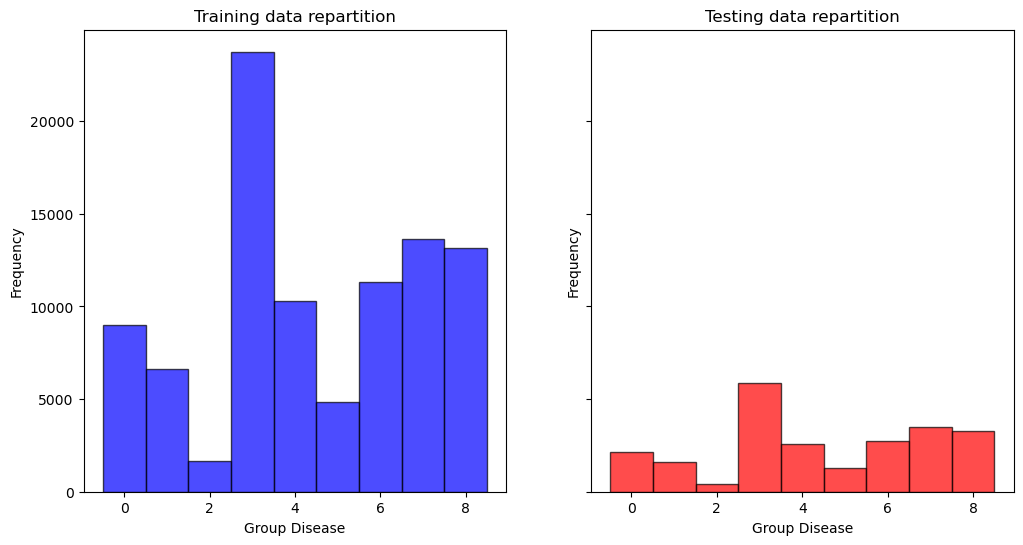

```python
plt.figure()
fig, axes = plt.subplots(1, 2, figsize=(12, 6), sharey=True)
axes[0].hist(Y_train, bins=np.arange(0, 10) - 0.5, edgecolor="black", alpha=0.7, color="blue")
axes[1].hist(Y_test, bins = np.arange(0,10) - 0.5, edgecolor = "black", alpha = 0.7, color = "red")
axes[0].set(title='Training data repartition', ylabel='Frequency', xlabel='Group Disease')
axes[1].set(title='Testing data repartition', ylabel='Frequency', xlabel='Group Disease')
plt.show
```

We could play with the splitting repartition: here it looks satisfying tho

Outline to do: * Vary features selections and compare * Vary models / process * Plot nice graphs (eg confusion matrix) * Research question? * READ RELATED PAPERS * Fonction qui a symptomes associe maladie

Following the outline of the exercise_S4, we test different models. We already know that we are in a classification problem, and thus computing the MSE seems unrelevant; the MSE would be greater if class 9 is predicted as class 1 than if class 9 is predicted as class 8, which does not mean anything in a classification problem. Thus we focus on precision, recall and f1-score, namely with confusion matrix.

Here are the definition of these metrics (as written in exercise s4):

```
- A confusion matrix is a table giving the false positive, the false negative, the true positive and the true negative.
- The precision measures how often a machine learning model correctly predicts the positive class. It is then computed as TP/ (TP + FP) where TP are true positive, and FP false positive.
- The Recall stat measures how often a machine learning model correctly identifies positive instances (true positives) from all the actual positive samples in the dataset. It is computed as TP/P (number of true positive on the number of positives)
- The Fscore summarize a classification model accuracy. It is computed as 2 * (precision * recall) / (precision + recall).
```

```python
# Imports
from sklearn.metrics import confusion_matrix, precision_score, recall_score, f1_score
from sklearn.tree import DecisionTreeClassifier
from sklearn.neighbors import KNeighborsClassifier
from sklearn.ensemble import BaggingClassifier, GradientBoostingClassifier
from sklearn.model_selection import KFold
import time

# Prepare data as numpy arrays
X = df_method1[[col for col in df_method1.columns if col not in ['group diseases', 'diseases', 'Response']]].to_numpy()
Y = df_method1["Response"].to_numpy()

# Models dictionary with CONSTRUCTORS (not instances)
models = {
    "Decision Trees (CART)": DecisionTreeClassifier,
    "k Nearest Neighbors (kNN)": lambda: KNeighborsClassifier(n_neighbors=5, n_jobs=-1),  # n_jobs=-1 for parallelization
    "Bagging Trees": BaggingClassifier,
    "Boosting Trees": lambda: GradientBoostingClassifier(max_depth=3, learning_rate=0.1, n_estimators=50)  # Faster params
}

# k-folds Cross-validation setup
k = 5  # Number of folds
kf = KFold(n_splits=k, shuffle=True, random_state=seed_n)

# Storage for results
results_method1 = {}

# Iterate over models
for model_name, ModelClass in models.items():
    print(f"\n{'='*60}")
    print(f"Evaluating model: {model_name}")
    print(f"{'='*60}")

    fold_conf_matrices = []  # To store confusion matrices for each fold
    fold_precision = []      # To store precision scores for each fold
    fold_recall = []         # To store recall scores for each fold
    fold_fscore = []         # To store F1 scores for each fold

    # Cross-validation loop
    fold_num = 1
    for train_index, test_index in kf.split(X):
        start_time = time.time()

        # Split the data into training and testing sets
        X_train, X_test = X[train_index], X[test_index]
        Y_train, Y_test = Y[train_index], Y[test_index]

        # CREATE A FRESH MODEL INSTANCE FOR THIS FOLD
        if callable(ModelClass):
            model = ModelClass()
        else:
            model = ModelClass

        # Train the model
        model.fit(X_train, Y_train)

        # Predict on the test set
        Y_pred = model.predict(X_test)

        # Compute confusion matrix
        conf_matrix = confusion_matrix(Y_test, Y_pred, labels=np.unique(Y))
        fold_conf_matrices.append(conf_matrix)

        # Compute standard precision, recall and F1-score
        precision = precision_score(Y_test, Y_pred, average="macro", zero_division=1)
        recall = recall_score(Y_test, Y_pred, average="macro", zero_division=1)
        fscore = f1_score(Y_test, Y_pred, average="macro", zero_division=1)
        fold_precision.append(precision)
        fold_recall.append(recall)
        fold_fscore.append(fscore)

        elapsed = time.time() - start_time
        print(f"  Fold {fold_num}/{k} - Time: {elapsed:.2f}s - Precision: {precision:.3f}, Recall: {recall:.3f}, F1: {fscore:.3f}")

        fold_num += 1

    # Average precision, recall and F1 score across all folds
    avg_precision = np.mean(fold_precision)
    avg_recall = np.mean(fold_recall)
    avg_fscore = np.mean(fold_fscore)

    # Convert list of confusion matrices to a 3D numpy array, and compute its average
    conf_matrices = np.array(fold_conf_matrices)
    mean_conf_matrix = np.mean(conf_matrices, axis=0)

    # Store results
    results_method1[model_name] = {
        "Confusion Matrices": fold_conf_matrices,
        "Mean CM": mean_conf_matrix,
        "Average Precision": avg_precision,
        "Average Recall": avg_recall,
        "Average F1 score": avg_fscore
    }

# Display final results
print("\n" + "="*60)
print("FINAL RESULTS (Cross-Validation)")
print("="*60)
for name, metrics in results_method1.items():
    print(f"\n{name}:")
    print(f"  Average Precision: {metrics['Average Precision']:.4f}")
    print(f"  Average Recall: {metrics['Average Recall']:.4f}")
    print(f"  Average F1-score: {metrics['Average F1 score']:.4f}")
```

[output not shown]

Then, we choose to stay stil very close to the exercise_s4, as we were given a classification analysis in good conditions. We keep in mind that the objective is to play with those once we have a working model, to see how they behave. Thus the next step is to plot confusion matrixes; we will see later how to plot them in a nice way.

```python
import matplotlib.pyplot as plt

def plot_mean_cm(mean_cm: np.array, model_name: str):
    """
    Plot the provided mean Confusion Matrix as a readable percentage heatmap.
    The model name used to produce the CM is also required to be plotted in the title.
    """
    # Convert to percentages
    percent_conf_matrix = mean_cm / mean_cm.sum(axis=1, keepdims=True) * 100

    # Plot the confusion matrix as a heatmap
    fig, ax = plt.subplots(figsize=(8, 6))
    cax = ax.matshow(percent_conf_matrix, cmap="RdYlGn_r")

    # Add colorbar with label
    cbar = fig.colorbar(cax)
    cbar.set_label('Percentage (%)', fontsize=12)

    # Annotate each cell with the percentage value
    for i in range(percent_conf_matrix.shape[0]):
        for j in range(percent_conf_matrix.shape[1]):
            text_color = "white" if percent_conf_matrix[i, j] > 50 else "black"
            ax.text(
                j, i, f"{percent_conf_matrix[i, j]:.2f}%",
                ha="center", va="center", color=text_color, fontsize=10
            )

    # Set axis labels and title
    ax.set_xticks(range(percent_conf_matrix.shape[1]))
    ax.set_yticks(range(percent_conf_matrix.shape[0]))
    ax.set_xticklabels([f"Pred {i}" for i in range(percent_conf_matrix.shape[1])], fontsize=10)
    ax.set_yticklabels([f"True {i}" for i in range(percent_conf_matrix.shape[0])], fontsize=10)
    ax.set_xlabel("Predicted Label", fontsize=12)
    ax.set_ylabel("True Label", fontsize=12)
    ax.set_title(f"Mean Confusion Matrix (as %) for {model_name}", fontsize=14)

    # Improve layout
    plt.tight_layout()
    plt.show()
```

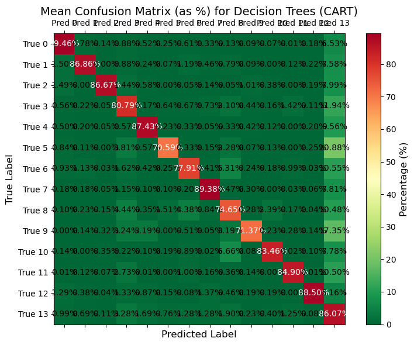

```python
plot_mean_cm(mean_cm = results_method1["Decision Trees (CART)"]["Mean CM"], model_name = "Decision Trees (CART)")
```

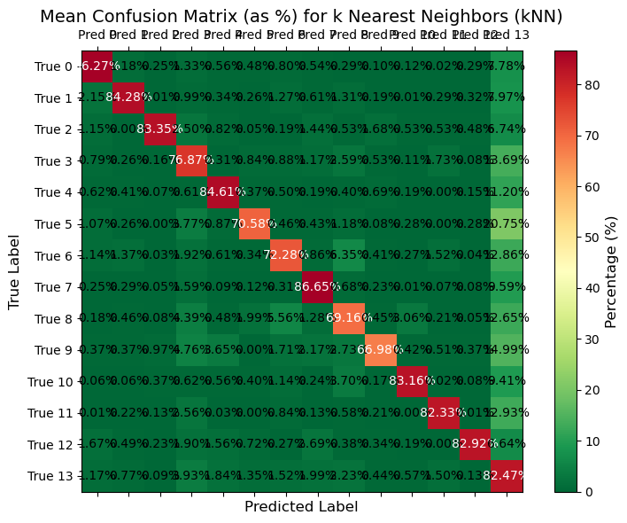

```python
plot_mean_cm(mean_cm = results_method1["k Nearest Neighbors (kNN)"]["Mean CM"], model_name = "k Nearest Neighbors (kNN)")
```

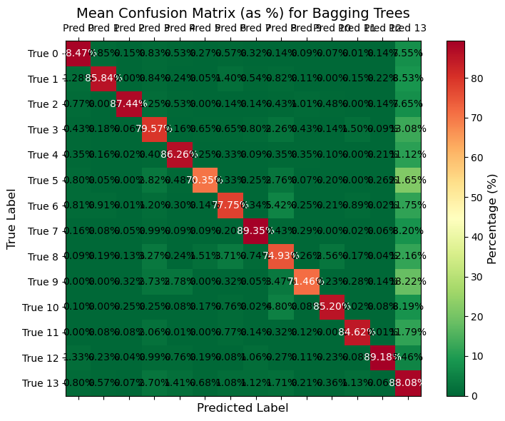

```python
plot_mean_cm(mean_cm = results_method1["Bagging Trees"]["Mean CM"], model_name = "Bagging Trees")
```

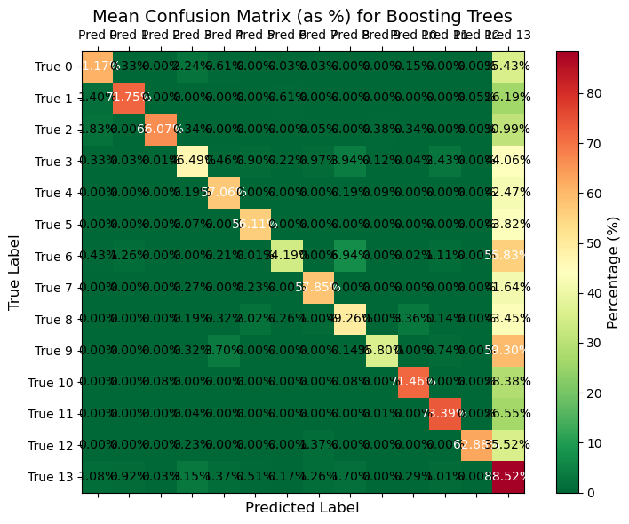

```python
plot_mean_cm(mean_cm = results_method1["Boosting Trees"]["Mean CM"], model_name = "Boosting Trees")
```

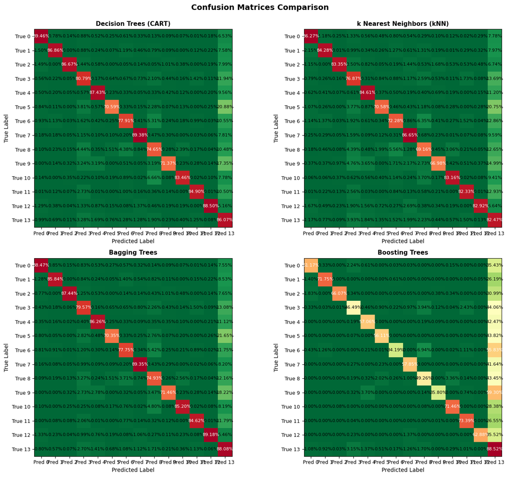

```python
import matplotlib.pyplot as plt
import numpy as np

# Create a 2x2 subplot grid
fig, axes = plt.subplots(2, 2, figsize=(14, 12))
axes = axes.flatten()

# Define the models in the desired order
models_order = [
    ("Decision Trees (CART)", 0),      # Top left
    ("k Nearest Neighbors (kNN)", 1),  # Top right
    ("Bagging Trees", 2),              # Bottom left
    ("Boosting Trees", 3)              # Bottom right
]

for model_name, position in models_order:
    ax = axes[position]
    mean_cm = results_method1[model_name]["Mean CM"]

    # Convert to percentages
    percent_conf_matrix = mean_cm / mean_cm.sum(axis=1, keepdims=True) * 100

    # Plot the confusion matrix as a heatmap
    im = ax.imshow(percent_conf_matrix, cmap="RdYlGn_r")

    # Annotate each cell with the percentage value
    for i in range(percent_conf_matrix.shape[0]):
        for j in range(percent_conf_matrix.shape[1]):
            text_color = "white" if percent_conf_matrix[i, j] > 50 else "black"
            ax.text(
                j, i, f"{percent_conf_matrix[i, j]:.2f}%",
                ha="center", va="center", color=text_color, fontsize=8
            )

    # Set axis labels and title
    ax.set_xticks(range(percent_conf_matrix.shape[1]))
    ax.set_yticks(range(percent_conf_matrix.shape[0]))
    ax.set_xticklabels([f"Pred {i}" for i in range(percent_conf_matrix.shape[1])], fontsize=9)
    ax.set_yticklabels([f"True {i}" for i in range(percent_conf_matrix.shape[0])], fontsize=9)
    ax.set_xlabel("Predicted Label", fontsize=10)
    ax.set_ylabel("True Label", fontsize=10)
    ax.set_title(f"{model_name}", fontsize=11, fontweight='bold')

# Add a shared colorbar
#fig.colorbar(im, ax=axes, label='Percentage (%)', fraction=0.046, pad=0.02)
fig.suptitle('Confusion Matrices Comparison', fontsize=14, fontweight='bold', y=0.995)
plt.tight_layout()
plt.show()
```

We could mention to which extent are our features imbalanced (way too much "other" namely). We know how to resolve this: weighted metrics.

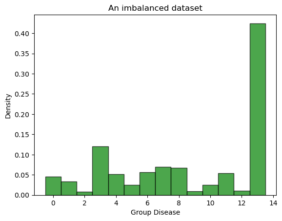

```python
plt.hist(df_method1["Response"], bins=np.arange(0, 15) - 0.5, edgecolor="black", alpha=0.7, color="green", density=True)
plt.title("An imbalanced dataset")
plt.xlabel("Group Disease")
plt.ylabel("Density")
```

We should (at least for the PDF version), find a nice way to plot confusion matrixes.

```python
# Imports
from sklearn.metrics import classification_report
from sklearn.metrics import confusion_matrix, precision_score, recall_score, f1_score
from sklearn.tree import DecisionTreeClassifier
from sklearn.neighbors import KNeighborsClassifier
from sklearn.ensemble import BaggingClassifier
from sklearn.model_selection import KFold

# Convert X and Y to numpy arrays to avoid indexing issues with KFold
X = df_method1[[col for col in df_cleaned.columns if col not in ['group diseases', 'diseases', 'Response']]].to_numpy()
Y = df_method1["Response"].to_numpy()

# Storage for results
results_method1_w = {}
models_2 = {
    "Decision Trees (CART)": DecisionTreeClassifier,
    "k Nearest Neighbors (kNN)": lambda: KNeighborsClassifier(n_neighbors=5, n_jobs=-1),
    "Bagging Trees": BaggingClassifier,
}

k = 5  # Number of folds
kf = KFold(n_splits=k, shuffle=True, random_state=seed_n)

# Iterate over models
for name, ModelClass in models_2.items():
    print(f"\n{'='*60}")
    print(f"Evaluating model: {name}")
    print(f"{'='*60}")

    fold_conf_matrices = []   # To store confusion matrices for each fold
    fold_precision = []       # To store precision scores for each fold
    fold_recall = []          # To store recall scores for each fold
    fold_fscore = []          # To store F1 scores for each fold
    fold_w_precision = []     # To store weighted precision scores for each fold
    fold_w_recall = []        # To store weighted recall scores for each fold
    fold_w_fscore = []        # To store weighted F1 scores for each fold

    # Cross-validation loop
    fold_num = 1
    for train_index, test_index in kf.split(X):
        # Split the data into training and testing sets using integer indexing
        X_train, X_test = X[train_index], X[test_index]
        Y_train, Y_test = Y[train_index], Y[test_index]

        # CREATE A FRESH MODEL INSTANCE FOR THIS FOLD
        if callable(ModelClass):
            model = ModelClass()
        else:
            model = ModelClass

        # Train the model
        model.fit(X_train, Y_train)

        # Predict on the test set
        Y_pred = model.predict(X_test)

        # Compute confusion matrix
        conf_matrix = confusion_matrix(Y_test, Y_pred, labels=np.unique(Y))
        fold_conf_matrices.append(conf_matrix)

        # Compute standard precision, recall and F1-score
        precision = precision_score(Y_test, Y_pred, average="macro", zero_division=1)
        recall = recall_score(Y_test, Y_pred, average="macro", zero_division=1)
        fscore = f1_score(Y_test, Y_pred, average="macro", zero_division=1)
        fold_precision.append(precision)
        fold_recall.append(recall)
        fold_fscore.append(fscore)

        # Generate a classification report with weighted metrics
        report = classification_report(Y_test, Y_pred, output_dict=True, zero_division=1)
        fold_w_precision.append(report['weighted avg']['precision'])
        fold_w_recall.append(report['weighted avg']['recall'])
        fold_w_fscore.append(report['weighted avg']['f1-score'])

        print(f"  Fold {fold_num}/{k} - Precision: {precision:.3f}, Weighted: {report['weighted avg']['precision']:.3f}")
        fold_num += 1

    # Average precision, recall and F1 score across all folds
    avg_precision = np.mean(fold_precision)
    avg_recall = np.mean(fold_recall)
    avg_fscore = np.mean(fold_fscore)

    # Average weighted precision, recall and F1 score across all folds
    avg_w_precision = np.mean(fold_w_precision)
    avg_w_recall = np.mean(fold_w_recall)
    avg_w_fscore = np.mean(fold_w_fscore)

    # Convert list of confusion matrices to a 3D numpy array, and compute its average
    conf_matrices = np.array(fold_conf_matrices)
    mean_conf_matrix = np.mean(conf_matrices, axis=0)

    # Store results
    results_method1_w[name] = {
        "Mean CM": mean_conf_matrix,
        "Average Precision": avg_precision,
        "Average Recall": avg_recall,
        "Average F1 score": avg_fscore,
        "Weighted avg Precision": avg_w_precision,
        "Weighted avg Recall": avg_w_recall,
        "Weighted avg F1score": avg_w_fscore
    }

# Display final results
print("\n" + "="*60)
print("FINAL RESULTS (Cross-Validation)")
print("="*60)
for name, metrics in results_method1_w.items():
    print(f"\n{name}:")
    print(f"  Average Precision: {metrics['Average Precision']:.4f}")
    print(f"  Average Weighted Precision: {metrics['Weighted avg Precision']:.4f}")
    print(f"  Average Recall: {metrics['Average Recall']:.4f}")
    print(f"  Average Weighted Recall: {metrics['Weighted avg Recall']:.4f}")
    print(f"  Average F1-score: {metrics['Average F1 score']:.4f}")
    print(f"  Average Weighted F1-score: {metrics['Weighted avg F1score']:.4f}")
```

```
============================================================
Evaluating model: Decision Trees (CART)
============================================================
  Fold 1/5 - Precision: 0.832, Weighted: 0.843
  Fold 2/5 - Precision: 0.836, Weighted: 0.844
  Fold 3/5 - Precision: 0.829, Weighted: 0.841
  Fold 4/5 - Precision: 0.829, Weighted: 0.838
  Fold 5/5 - Precision: 0.831, Weighted: 0.839

============================================================
Evaluating model: k Nearest Neighbors (kNN)
============================================================
  Fold 1/5 - Precision: 0.789, Weighted: 0.807
  Fold 2/5 - Precision: 0.782, Weighted: 0.809
  Fold 3/5 - Precision: 0.780, Weighted: 0.805
  Fold 4/5 - Precision: 0.786, Weighted: 0.803
  Fold 5/5 - Precision: 0.787, Weighted: 0.807

============================================================
Evaluating model: Bagging Trees
============================================================
  Fold 1/5 - Precision: 0.844, Weighted: 0.846
  Fold 2/5 - Precision: 0.847, Weighted: 0.850
  Fold 3/5 - Precision: 0.839, Weighted: 0.846
  Fold 4/5 - Precision: 0.837, Weighted: 0.843
  Fold 5/5 - Precision: 0.843, Weighted: 0.846

============================================================
FINAL RESULTS (Cross-Validation)
============================================================

Decision Trees (CART):
  Average Precision: 0.8313
  Average Weighted Precision: 0.8408
  Average Recall: 0.8274
  Average Weighted Recall: 0.8410
  Average F1-score: 0.8291
  Average Weighted F1-score: 0.8408

k Nearest Neighbors (kNN):
  Average Precision: 0.7847
  Average Weighted Precision: 0.8061
  Average Recall: 0.7941
  Average Weighted Recall: 0.8056
  Average F1-score: 0.7887
  Average Weighted F1-score: 0.8056

Bagging Trees:
  Average Precision: 0.8420
  Average Weighted Precision: 0.8461
  Average Recall: 0.8281
  Average Weighted Recall: 0.8463
  Average F1-score: 0.8347
  Average Weighted F1-score: 0.8459
```

```python
# Save results to disk using joblib
import joblib

# Save after training
joblib.dump(results_method1, 'results_method1.pkl')
joblib.dump(results_method1_w, 'results_method1_w.pkl')

print("Results saved successfully!")
```

```
Results saved successfully!
```

The weighted Metrix of Bagging Trees and Decision Trees are somewhat similar, though Bagging Trees seems to perform better.

## 2. With Method 2: Lasso selection

```python
# Imports
import pandas as pd
import numpy as np
import matplotlib.pyplot as plt
from sklearn.model_selection import train_test_split

# Instanciate needed parameters and set the random seed to be reproductible
test_ratio = 0.2
seed_n = 42
np.random.seed(seed_n)

# Define X and Y
X = df_method2[[col for col in df_method2.columns if col not in ['group diseases']or col not in ['diseases'] or col not in ['Response']]]
Y = df_method2["Response"]

# Split the dataset into training and testing sets
X_train, X_test, Y_train, Y_test = train_test_split(X, Y, test_size=test_ratio, random_state=seed_n)
```

```python
# Imports
from sklearn.metrics import confusion_matrix, precision_score, recall_score, f1_score
from sklearn.tree import DecisionTreeClassifier
from sklearn.neighbors import KNeighborsClassifier
from sklearn.ensemble import BaggingClassifier, GradientBoostingClassifier
from sklearn.model_selection import KFold
import time

# Prepare data as numpy arrays
X = df_method2[[col for col in df_method2.columns if col not in ['group diseases', 'diseases', 'Response']]].to_numpy()
Y = df_method2["Response"].to_numpy()

# Models dictionary with CONSTRUCTORS (not instances)
models = {
    "Decision Trees (CART)": DecisionTreeClassifier,
    "k Nearest Neighbors (kNN)": lambda: KNeighborsClassifier(n_neighbors=5, n_jobs=-1),  # n_jobs=-1 for parallelization
    "Bagging Trees": BaggingClassifier,
}

# k-folds Cross-validation setup
k = 5  # Number of folds
kf = KFold(n_splits=k, shuffle=True, random_state=seed_n)

# Storage for results
results_method2 = {}

# Iterate over models
for model_name, ModelClass in models.items():
    print(f"\n{'='*60}")
    print(f"Evaluating model: {model_name}")
    print(f"{'='*60}")

    fold_conf_matrices = []  # To store confusion matrices for each fold
    fold_precision = []      # To store precision scores for each fold
    fold_recall = []         # To store recall scores for each fold
    fold_fscore = []         # To store F1 scores for each fold

    # Cross-validation loop
    fold_num = 1
    for train_index, test_index in kf.split(X):
        start_time = time.time()

        # Split the data into training and testing sets
        X_train, X_test = X[train_index], X[test_index]
        Y_train, Y_test = Y[train_index], Y[test_index]

        # CREATE A FRESH MODEL INSTANCE FOR THIS FOLD
        if callable(ModelClass):
            model = ModelClass()
        else:
            model = ModelClass

        # Train the model
        model.fit(X_train, Y_train)

        # Predict on the test set
        Y_pred = model.predict(X_test)

        # Compute confusion matrix
        conf_matrix = confusion_matrix(Y_test, Y_pred, labels=np.unique(Y))
        fold_conf_matrices.append(conf_matrix)

        # Compute standard precision, recall and F1-score
        precision = precision_score(Y_test, Y_pred, average="macro", zero_division=1)
        recall = recall_score(Y_test, Y_pred, average="macro", zero_division=1)
        fscore = f1_score(Y_test, Y_pred, average="macro", zero_division=1)
        fold_precision.append(precision)
        fold_recall.append(recall)
        fold_fscore.append(fscore)

        elapsed = time.time() - start_time
        print(f"  Fold {fold_num}/{k} - Time: {elapsed:.2f}s - Precision: {precision:.3f}, Recall: {recall:.3f}, F1: {fscore:.3f}")

        fold_num += 1

    # Average precision, recall and F1 score across all folds
    avg_precision = np.mean(fold_precision)
    avg_recall = np.mean(fold_recall)
    avg_fscore = np.mean(fold_fscore)

    # Convert list of confusion matrices to a 3D numpy array, and compute its average
    conf_matrices = np.array(fold_conf_matrices)
    mean_conf_matrix = np.mean(conf_matrices, axis=0)

    # Store results
    results_method2[model_name] = {
        "Confusion Matrices": fold_conf_matrices,
        "Mean CM": mean_conf_matrix,
        "Average Precision": avg_precision,
        "Average Recall": avg_recall,
        "Average F1 score": avg_fscore
    }

# Display final results
print("\n" + "="*60)
print("FINAL RESULTS (Cross-Validation)")
print("="*60)
for name, metrics in results_method2.items():
    print(f"\n{name}:")
    print(f"  Average Precision: {metrics['Average Precision']:.4f}")
    print(f"  Average Recall: {metrics['Average Recall']:.4f}")
    print(f"  Average F1-score: {metrics['Average F1 score']:.4f}")
```

```
============================================================
Evaluating model: Decision Trees (CART)
============================================================
  Fold 1/5 - Time: 38.79s - Precision: 0.876, Recall: 0.888, F1: 0.882
  Fold 2/5 - Time: 36.77s - Precision: 0.876, Recall: 0.891, F1: 0.883
  Fold 3/5 - Time: 37.18s - Precision: 0.878, Recall: 0.886, F1: 0.882
  Fold 4/5 - Time: 38.45s - Precision: 0.873, Recall: 0.886, F1: 0.880
  Fold 5/5 - Time: 37.11s - Precision: 0.875, Recall: 0.890, F1: 0.882

============================================================
Evaluating model: k Nearest Neighbors (kNN)
============================================================
  Fold 1/5 - Time: 370.95s - Precision: 0.888, Recall: 0.895, F1: 0.891
  Fold 2/5 - Time: 360.43s - Precision: 0.892, Recall: 0.894, F1: 0.893
  Fold 3/5 - Time: 354.15s - Precision: 0.890, Recall: 0.888, F1: 0.889
  Fold 4/5 - Time: 348.05s - Precision: 0.888, Recall: 0.884, F1: 0.886
  Fold 5/5 - Time: 359.39s - Precision: 0.890, Recall: 0.893, F1: 0.891

============================================================
Evaluating model: Bagging Trees
============================================================
  Fold 1/5 - Time: 238.56s - Precision: 0.897, Recall: 0.894, F1: 0.895
  Fold 2/5 - Time: 238.41s - Precision: 0.901, Recall: 0.896, F1: 0.898
  Fold 3/5 - Time: 246.64s - Precision: 0.896, Recall: 0.890, F1: 0.893
  Fold 4/5 - Time: 234.64s - Precision: 0.897, Recall: 0.893, F1: 0.895
  Fold 5/5 - Time: 229.82s - Precision: 0.899, Recall: 0.895, F1: 0.897

============================================================
FINAL RESULTS (Cross-Validation)
============================================================

Decision Trees (CART):
  Average Precision: 0.8756
  Average Recall: 0.8884
  Average F1-score: 0.8818

k Nearest Neighbors (kNN):
  Average Precision: 0.8898
  Average Recall: 0.8909
  Average F1-score: 0.8902

Bagging Trees:
  Average Precision: 0.8980
  Average Recall: 0.8935
  Average F1-score: 0.8957
```

```python
# Save results to disk using joblib
import joblib

# Save after training
joblib.dump(results_method2, 'results_method2.pkl')

print("Results saved successfully!")
```

```
Results saved successfully!
```

## 3. With Method 3: RFE

We replicate what we have done in previous section, focusing on the results we could have with this RFE method.

```python
# Imports
import pandas as pd
import numpy as np
import matplotlib.pyplot as plt
from sklearn.model_selection import train_test_split

# Instanciate needed parameters and set the random seed to be reproductible
test_ratio = 0.2
seed_n = 42
np.random.seed(seed_n)

# Define X and Y
X = df_method3[[col for col in df_method3.columns if col not in ['group diseases']or col not in ['diseases'] or col not in ['Response']]]
Y = df_method3["Response"]

# Split the dataset into training and testing sets
X_train, X_test, Y_train, Y_test = train_test_split(X, Y, test_size=test_ratio, random_state=seed_n)
```

```python
# Imports
from sklearn.metrics import confusion_matrix, precision_score, recall_score, f1_score
from sklearn.tree import DecisionTreeClassifier
from sklearn.neighbors import KNeighborsClassifier
from sklearn.ensemble import BaggingClassifier, GradientBoostingClassifier
from sklearn.model_selection import KFold
import time

# Prepare data as numpy arrays
X = df_method3[[col for col in df_method3.columns if col not in ['group diseases', 'diseases', 'Response']]].to_numpy()
Y = df_method3["Response"].to_numpy()

# Models dictionary with CONSTRUCTORS (not instances)
models = {
    "Decision Trees (CART)": DecisionTreeClassifier,
    "k Nearest Neighbors (kNN)": lambda: KNeighborsClassifier(n_neighbors=5, n_jobs=-1),  # n_jobs=-1 for parallelization
    "Bagging Trees": BaggingClassifier,
}

# k-folds Cross-validation setup
k = 5  # Number of folds
kf = KFold(n_splits=k, shuffle=True, random_state=seed_n)

# Storage for results
results_method3 = {}

# Iterate over models
for model_name, ModelClass in models.items():
    print(f"\n{'='*60}")
    print(f"Evaluating model: {model_name}")
    print(f"{'='*60}")

    fold_conf_matrices = []  # To store confusion matrices for each fold
    fold_precision = []      # To store precision scores for each fold
    fold_recall = []         # To store recall scores for each fold
    fold_fscore = []         # To store F1 scores for each fold

    # Cross-validation loop
    fold_num = 1
    for train_index, test_index in kf.split(X):
        start_time = time.time()

        # Split the data into training and testing sets
        X_train, X_test = X[train_index], X[test_index]
        Y_train, Y_test = Y[train_index], Y[test_index]

        # CREATE A FRESH MODEL INSTANCE FOR THIS FOLD
        if callable(ModelClass):
            model = ModelClass()
        else:
            model = ModelClass

        # Train the model
        model.fit(X_train, Y_train)

        # Predict on the test set
        Y_pred = model.predict(X_test)

        # Compute confusion matrix
        conf_matrix = confusion_matrix(Y_test, Y_pred, labels=np.unique(Y))
        fold_conf_matrices.append(conf_matrix)

        # Compute standard precision, recall and F1-score
        precision = precision_score(Y_test, Y_pred, average="macro", zero_division=1)
        recall = recall_score(Y_test, Y_pred, average="macro", zero_division=1)
        fscore = f1_score(Y_test, Y_pred, average="macro", zero_division=1)
        fold_precision.append(precision)
        fold_recall.append(recall)
        fold_fscore.append(fscore)

        elapsed = time.time() - start_time
        print(f"  Fold {fold_num}/{k} - Time: {elapsed:.2f}s - Precision: {precision:.3f}, Recall: {recall:.3f}, F1: {fscore:.3f}")

        fold_num += 1

    # Average precision, recall and F1 score across all folds
    avg_precision = np.mean(fold_precision)
    avg_recall = np.mean(fold_recall)
    avg_fscore = np.mean(fold_fscore)

    # Convert list of confusion matrices to a 3D numpy array, and compute its average
    conf_matrices = np.array(fold_conf_matrices)
    mean_conf_matrix = np.mean(conf_matrices, axis=0)

    # Store results
    results_method3[model_name] = {
        "Confusion Matrices": fold_conf_matrices,
        "Mean CM": mean_conf_matrix,
        "Average Precision": avg_precision,
        "Average Recall": avg_recall,
        "Average F1 score": avg_fscore
    }

# Display final results
print("\n" + "="*60)
print("FINAL RESULTS (Cross-Validation)")
print("="*60)
for name, metrics in results_method3.items():
    print(f"\n{name}:")
    print(f"  Average Precision: {metrics['Average Precision']:.4f}")
    print(f"  Average Recall: {metrics['Average Recall']:.4f}")
    print(f"  Average F1-score: {metrics['Average F1 score']:.4f}")
```

```
============================================================
Evaluating model: Decision Trees (CART)
============================================================
  Fold 1/5 - Time: 14.28s - Precision: 0.776, Recall: 0.580, F1: 0.628
  Fold 2/5 - Time: 13.69s - Precision: 0.783, Recall: 0.586, F1: 0.634
  Fold 3/5 - Time: 14.35s - Precision: 0.776, Recall: 0.580, F1: 0.627
  Fold 4/5 - Time: 14.39s - Precision: 0.793, Recall: 0.574, F1: 0.626
  Fold 5/5 - Time: 13.54s - Precision: 0.781, Recall: 0.587, F1: 0.635

============================================================
Evaluating model: k Nearest Neighbors (kNN)
============================================================
  Fold 1/5 - Time: 360.24s - Precision: 0.564, Recall: 0.525, F1: 0.532
  Fold 2/5 - Time: 339.39s - Precision: 0.579, Recall: 0.517, F1: 0.527
  Fold 3/5 - Time: 339.27s - Precision: 0.605, Recall: 0.527, F1: 0.544
  Fold 4/5 - Time: 321.78s - Precision: 0.627, Recall: 0.537, F1: 0.556
  Fold 5/5 - Time: 337.63s - Precision: 0.630, Recall: 0.539, F1: 0.569

============================================================
Evaluating model: Bagging Trees
============================================================
  Fold 1/5 - Time: 87.28s - Precision: 0.797, Recall: 0.572, F1: 0.627
  Fold 2/5 - Time: 85.78s - Precision: 0.804, Recall: 0.574, F1: 0.630
  Fold 3/5 - Time: 84.08s - Precision: 0.779, Recall: 0.577, F1: 0.626
  Fold 4/5 - Time: 85.04s - Precision: 0.795, Recall: 0.575, F1: 0.627
  Fold 5/5 - Time: 85.16s - Precision: 0.782, Recall: 0.585, F1: 0.634

============================================================
FINAL RESULTS (Cross-Validation)
============================================================

Decision Trees (CART):
  Average Precision: 0.7816
  Average Recall: 0.5814
  Average F1-score: 0.6300

k Nearest Neighbors (kNN):
  Average Precision: 0.6009
  Average Recall: 0.5289
  Average F1-score: 0.5457

Bagging Trees:
  Average Precision: 0.7913
  Average Recall: 0.5765
  Average F1-score: 0.6288
```

Once again, Bagging Trees and Decision Trees have pretty good results, though the results all seem worse than Method 1's results.

```python
# Save results to disk using joblib
import joblib

# Save after training
joblib.dump(results_method3, 'results_method3.pkl')

print("Results saved successfully!")
```

```
Results saved successfully!
```

# Comparison of our different feature selection methods

```python
# Load previously saved results (instead of rerunning the cross-validation)
import joblib

try:
    results_method1 = joblib.load('results_method1.pkl')
    results_method1_w = joblib.load('results_method1_w.pkl')
    results_method3 = joblib.load('results_method3.pkl')
    print("Results loaded successfully!")
except FileNotFoundError:
    print("Results files not found. You need to run the training cells first.")
```

```
Results loaded successfully!
```

Now that we have tested our different models with our different models, lets compare the ones that seem the most relevant, using a nice graph.

```python
#We will plot a graph plotting the mean of the precision matrix percentage trace for each model
#
def trace_percentage(mean_cm: np.array):
    """
    Calculate the trace of the confusion matrix as a percentage of correct predictions.
    """
    correct_predictions = np.trace(mean_cm)
    total_predictions = np.sum(mean_cm)
    trace_percent = (correct_predictions / total_predictions) * 100
    return trace_percent
```

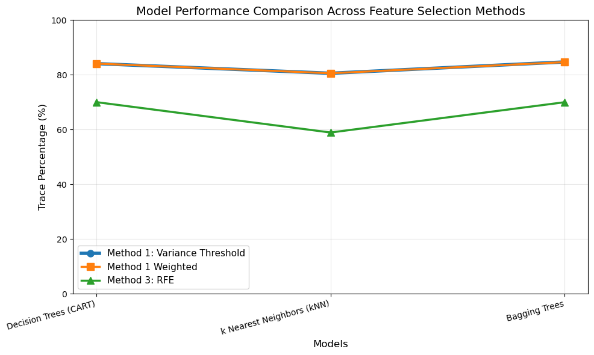

```python
#Now lets plot the trace percentage for each model

# Define the models we want to compare (in the order to display)
models_to_compare = ["Decision Trees (CART)", "k Nearest Neighbors (kNN)", "Bagging Trees"]

# Extract trace percentages for Method 1 (Variance Threshold)
method1_traces = [trace_percentage(results_method1[model]["Mean CM"]) for model in models_to_compare]

# Extract trace percentages for Method 1 Weighted
method1_w_traces = [trace_percentage(results_method1_w[model]["Mean CM"]) for model in models_to_compare]

#Extratt trace percentages for Method 3
method3_traces = [trace_percentage(results_method3[model]["Mean CM"]) for model in models_to_compare]

# Create the plot
plt.figure(figsize=(10, 6))
x_pos = np.arange(len(models_to_compare))
plt.plot(x_pos, method1_traces, marker='o', linewidth=4, label='Method 1: Variance Threshold', markersize=8, color='#1f77b4')
plt.plot(x_pos, method1_w_traces, marker='s', linewidth=2.5, label='Method 1 Weighted', markersize=8, color='#ff7f0e')
plt.plot(x_pos, method3_traces, marker='^', linewidth=2.5, label='Method 3: RFE', markersize=8, color='#2ca02c')
# Customize the plot
plt.xlabel('Models', fontsize=12)
plt.ylabel('Trace Percentage (%)', fontsize=12)
plt.title('Model Performance Comparison Across Feature Selection Methods', fontsize=14)
plt.xticks(x_pos, models_to_compare, rotation=15, ha='right')
plt.ylim([0, 100])
plt.grid(True, alpha=0.3)
plt.legend(fontsize=11)
plt.tight_layout()
plt.show()
```

```python
# Print the actual trace percentage values to see if they're different
print("Method 1 traces:", method1_traces)
print("Method 1 Weighted traces:", method1_w_traces)
print("Method 3 traces:", method3_traces)
print("\nDifferences (Method 1 - Method 1 Weighted):")
for i, model in enumerate(models_to_compare):
    diff = method1_traces[i] - method1_w_traces[i]
    print(f"  {model}: {diff:.4f}%")
```

```
Method 1 traces: [np.float64(84.0810706837555), np.float64(80.55963878596448), np.float64(84.6929478223896)]
Method 1 Weighted traces: [np.float64(84.09645872562716), np.float64(80.55963878596448), np.float64(84.63018080949199)]
Method 3 traces: [np.float64(70.00303711352731), np.float64(58.90825892405191), np.float64(69.98116989613071)]

Differences (Method 1 - Method 1 Weighted):
  Decision Trees (CART): -0.0154%
  k Nearest Neighbors (kNN): 0.0000%
  Bagging Trees: 0.0628%
```